As we have mentioned many times in class, both estimate and confidence interval are random variables. The explanation can be quite simple. Both estimate and confidence interval are the functions of random sample, that are actually set of random variables identically and independently distributed as population distribution. Mathematically, that is $X_1, \dots, X_n \sim i.i.d. F(\theta)$ and estimate of $\theta$, $\hat{\theta}$ is a function of $X_1, \dots, X_n$, that is $\hat{\theta}:(X_1, \dots, X_n) \rightarrow R$. And, if you check the confidence interval we have shown in class, you will find that it is also the function of random sample. So, both of them are random variables. This article will use simulation to help you to understand the uncertainty behind estimate and confidence interval.

## Understanding they are random variables

We are going to focus on the population which follows normal distribution with mean, $\mu = 5$ and variance $\sigma^2 = 2$. Now, let us pretend we do not know the true value of mean and we are going to estimate it with sample. So, first step is generating a sample from this distribution with sample size 500.

```r
set.seed(123)
sample1 <- rnorm(500, 5, sqrt(2)) ## this code will generate 500 random number from N(5, 2)
```

Before we move to next step, let’s plot the estimated density curve of our sample1. The black line is the density curve that is estimated from sample1 (so called empirical) and the red line is the density curve calculated from the probability density function (so called theoratical).

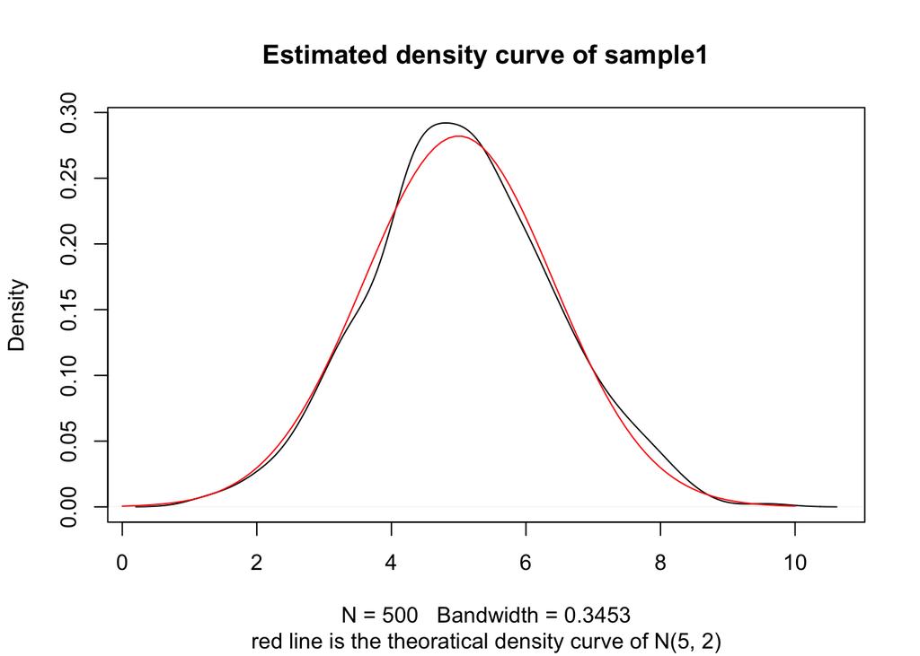

```r
plot.new()
plot(density(sample1), main = "Estimated density curve of sample1",
     sub = "red line is the theoratical density curve of N(5, 2)")
lines(seq(0, 10, length.out = 100), dnorm(seq(0, 10, length.out = 100), 5, sqrt(2)), col = "red")
```

Recall that, the popular estimator of population mean, $\mu$ is sample mean, $\bar{X} = 1/n\sum_{i=1}^n X_i$. Now, let us calulate the sample mean based on sample1 and use this sample mean as the estimator1 of population mean. As you can see, estimator1 of population mean, $\hat{\mu}_1$, is 5.0489 which is quite close to the true value 5. However, it is not equal to the true value!

```r
mean(sample1)
```

```
## [1] 5.048918
```

Now, let us calculate the $95\%$ confidence interval for population mean $\mu$ based on sample1. Because the random sample follows normal distribution and the variance is known as 2, the formula for confidence interval is
$$(\bar{X} - z_{\frac{\alpha}{2}} \frac{\sigma}{\sqrt{n}}, \bar{X} + z_{\frac{\alpha}{2}} \frac{\sigma}{\sqrt{n}}),$$
where $\bar{X}=5.0489$, $\alpha=0.05$, z-critical value $z_{\frac{\alpha}{2}}=1.96$, $\sigma = \sqrt{2}$ and sample size $n=500$. So, it can be evaluated by following code. Then, we will have $95\%$ confidence interval based on sample1 as (4.925, 5.173). Let us name this interval as CI1. I want to mention that this interval, CI1, does cover the true value of population mean, 5.

```r
CI95norm <- function(sample) {
  lb <- mean(sample)-1.96*(sqrt(2/500))
  ub <- mean(sample)+1.96*(sqrt(2/500))
  c(lb, ub)
}
CI95norm(sample1)
```

```
## [1] 4.924957 5.172880
```

Now, let us summary what we have done until now as following list: 1. Generate random sample with sample size 500 from N(5, 2). (that is sample1) 2. Calculate sample mean as estimator of population mean based on sample gotten in step 1. (that is estimator1, $\hat{\mu}_1$) 3. Calcualte $95%$ confidence interval based on sample gotten in step 1. (that is CI1) I want to mention that step 1 can be considered as we process an experiment one time and collect sample from this experiment. Now, let us replicate this procedure. Then, we can calculate the sample mean from sample2 and it is our estimator2 of population mean, $\hat{\mu}_2=4.982$. This number is very close to the true value 5 and is not equal to the $\hat{\mu}_1$, because they are calculated from different samples. Furthermore, the CI2 from sample2 is $(4.858, 5.106)$, which also covers the true value but not equal to CI1. The reason is random sample has uncertainty, that induces both estimator and confidence interval have uncertainty. They are random variables!

```r
set.seed(432)
sample2 <- rnorm(500, 5, sqrt(2)) ## this code will generate 500 random number from N(5, 2)
mean(sample2)
```

```
## [1] 4.98243
```

```r
CI95norm(sample2)
```

```
## [1] 4.858468 5.106391
```

## Understanding the meaning of unbiased estimator

The definition of unbiased estimator is $E(\hat{\theta}) = \theta$. In our example, $E(\hat{X}) = \mu$. So, $\hat{X}$ is the unbiased estimator of $\mu$. Even if each estimator, $\hat{X}$ can not target the true value 5, $\hat{X}$ can target the true value 5 **on average**.

Let us replicate the above procedure 1000 times. That will gives us 1000 different samples from N(5, 2). Each of them will have 500 observations. Then, 1000 estimators of population mean and 1000 $95\%$ CI can be evaluated from these samples. Let us do it!

```r
set.seed(837)
result <- matrix(NA, ncol = 4, nrow = 1000)
for (i in 1:1000) {
  sample <- rnorm(500, 5, sqrt(2))
  result[i, 1] <- i
  result[i, 2] <- mean(sample)
  result[i, 3:4] <- CI95norm(sample)
}
colnames(result) <- c("ID", "sample_mean", "95CI_lower", "95CI_upper")
head(result)
```

```
##      ID sample_mean 95CI_lower 95CI_upper
## [1,]  1    4.930987   4.807026   5.054949
## [2,]  2    5.128847   5.004885   5.252808
## [3,]  3    5.034153   4.910192   5.158115
## [4,]  4    4.929134   4.805173   5.053095
## [5,]  5    5.054067   4.930106   5.178028
## [6,]  6    5.006233   4.882272   5.130194
```

The result is shown as above table. (Only first 6 rows are shown.) Each row records the result of one experiment. `sample_mean` column records the estimator, $\hat{\mu}_j$, $j=1,\dots,1000$. `95CI_lower` and `95CI_upper` record the $95\%$ confidence interval’s lower bound and upper bound. Now, the average of first $m$ estimators is $1/m \sum_{j=1}^m \hat{\mu}_j$. $\hat{\mu}$ is unbiased basically tells us as $m \rightarrow \infty$, this average will process to 5. Let us plot this average vs $m$ and you will find it is the case.

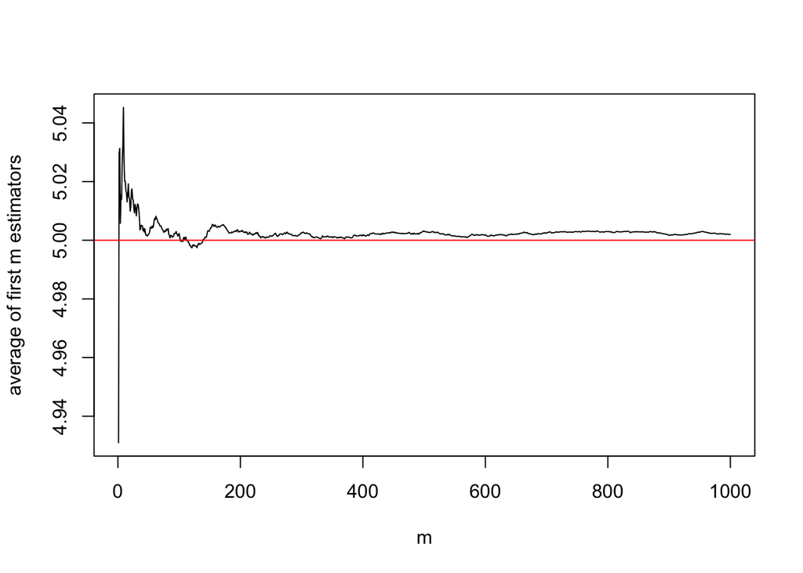

```r
aveEst <- numeric(1000)
for (i in 1:1000) {
  aveEst[i] <- mean(result[1:i, 2])
}
plot(1:1000, aveEst, type = "l", xlab = "m", ylab = "average of first m estimators")
abline(h = 5, col = "red")
```

## Understanding the confidence level in confidence interval

We have calculated 1000 $95\%$ confidence intervals based on 1000 samples we simulated. For a $95\%$ CI, the confidence level is $95\%$ and significant level is $(1-95\%) = 5\%$. The $95\%$ confidence level here means the probability of ‘confidence interval covers the true population mean 5’ is $95\%$ theoratically. Practically, it means within 1000 confidence intervals we got from simulation, about $95\%$ of them will cover the true value 5. Let us check whether it is the case. As shown in the following code, the proportion of intervals cover the true value 5 is $94.8\%$, that is very close to $95\%$.

```r
## show the proportion of intervals covering 5
sum(result[, 3] < 5 & result[, 4] > 5) / 1000
```

```
## [1] 0.948
```